# Anthony Fantano Ratings Pre-processing and EDA

The following document takes a deeper look at famous YouTube music reviewer Anthony Fantano’s album ratings. The data contains all reviews/scores of music albums rated by him, and was webscraped from rateyourmusic.com/~theneedledrop. *Analyzing his ratings on hip hop albums was an area of interest*

**Data Source:**

- fantano.csv

**Below is a list of variables that were of importance:**

```r
library(tidyverse)
```

#### Reading in data

```r
fantano <- read_csv("fantano.csv")
```

#### Filtering out NA values in total_length

```r
fantano_filter <- fantano %>%
  drop_na(total_length)
```

#### Creating new column that only contains only numeric value of total_length and with no white space

```r
fantano_filter <- fantano_filter %>%
  mutate(album_length = str_trim(str_to_lower(str_replace(fantano_filter$total_length, 'Total Length: ', ''))))
```

#### Creating new column that only contains minute value of album_length and converting those values to doubles

```r
fantano_filter <- fantano_filter %>%
  tidyr::extract(album_length, 'album_minutes_only', regex = '(\\d{1,} minute)', remove = F) %>%
  mutate(album_minutes_only = as.double(str_replace(album_minutes_only, 'minute', '')))
```

#### Creating new column that only contains hour value of album_length and creating new column that converts it to minutes

```r
fantano_filter<-fantano_filter%>%
  tidyr::extract(col=album_length,into = "hours", regex = "(\\d\\shour)", remove=F)%>%
  tidyr::extract(col=hours, into="hours", regex="(\\d)", remove=F)%>%
  mutate(hours_minutes=as.double(hours))%>%
  mutate(hours_minutes=hours_minutes*60)
```

#### Creating new column that sums hours_minutes and album_minutes_only to find total length of each album in minutes

```r
fantano_filter <- fantano_filter %>%
  rowwise() %>%
  mutate(total_length_minutes = sum(c(hours_minutes, album_minutes_only), na.rm = T))
```

#### Finding the album that had the longest length in minutes

```r
longest_album <- fantano_filter %>%
  arrange(desc(total_length_minutes)) %>%
  head(1) %>%
  pull(album)
```

```
## [1] "The Seer"
```

#### Creating a new column that is set to 1 if ‘hip hop’ is detected as a genre

```r
fantano <- fantano %>%
  mutate(hip_hop = ifelse(str_detect(tolower(genres), "hip hop"), 1, 0))
```

#### Creating a new column that finds the number of producers of each album

```r
fantano <- fantano %>%
  mutate(producer_number = stringr::str_count(producer, ",") + 1 )
```

#### Finding the hip hop album with the most amount of producers

```r
most_producers <- fantano %>%
  arrange(desc(producer_number)) %>%
  head(1) %>%
  pull(album)
```

```
## [1] "Slime Language 2"
```

#### Creating a new column in Fantano that is the release_date column in YYYY-MM-DD format, filtering to only include hip hop albums released in 2022.

#### Creating a new tibble that only contains the artist, album, and fantano_rating columns from Fantano data set

```r
fantano <- fantano %>%
  mutate(date = lubridate::mdy(release_date)) %>%
  filter(str_detect(date, "2022")) %>%
  filter(hip_hop == 1)
```

```r
fantano_graph <- fantano %>%
  select(artist, album, fantano_rating)
```

#### Loading in glue library and creating a new column that contains the artist and album name

```r
library(glue)
fantano_graph <- fantano_graph %>%
  mutate(artist_album = glue('{fantano_graph$artist}: {fantano_graph$album}'))
```

```r
fantano_graph_subset <- fantano_graph %>%
  arrange(desc(fantano_rating)) %>%
  head(15)
```

```
## # A tibble: 8 × 4
##   artist             album                         fantano_rating artist_album
##   <chr>              <chr>                                  <dbl> <glue>
## 1 Conway the Machine God Don't Make Mistakes                   90 Conway the Ma…
## 2 Billy Woods        Aethiopes                                 80 Billy Woods: …
## 3 Kendrick Lamar     Mr. Morale & The Big Steppers             80 Kendrick Lama…
## 4 Quelle Chris       Deathfame                                 70 Quelle Chris:…
## 5 The Cool Kids      BEFORE SHIT GOT WEIRD                     70 The Cool Kids…
## 6 EARTHGANG          Ghetto Gods                               70 EARTHGANG: Gh…
## 7 Yeat               2 Alivë                                   40 Yeat: 2 Alivë
## 8 $NOT               Ethereal                                  30 $NOT: Ethereal
```

[figure not shown]

```r
fantano_graph_final <- fantano_graph_subset %>%
  mutate(artist_album = fct_reorder(artist_album, fantano_rating)) %>%
  ggplot(aes(x = fantano_rating, y = artist_album)) +
  geom_col() +
  coord_cartesian(xlim = c(60,90)) +
  labs(x = "Fantano Score",
       y = "",
       title = "Top 15 Hip Hop Albums of 2022",
       subtitle = "Anthony Fantano Ratings") +
  theme_minimal()
```

#### Reloading fantano data

```r
fantano_writeup <- read_csv('fantano.csv')
popular_genres <- c('Hip Hop', 'Indie Rock', 'Trap', 'Southern Hip Hop', 'Alternative Rock', 'Electronic')
```

#### Finding the average difference between fantano_rating and critic_score for the top 10 highest rated fantano albums

```r
highest_fantano_ratings <- fantano_writeup %>%
  arrange(desc(fantano_rating)) %>%
  select(album, fantano_rating, critic_score) %>%
  mutate(difference = fantano_rating - critic_score) %>%
  head(10) %>%
  mutate(average_difference = mean(difference))
```

```
## # A tibble: 10 × 5
##    album                       fantano_rating critic_score difference average_…¹
##    <chr>                                <dbl>        <dbl>      <dbl>      <dbl>
##  1 SINNER GET READY                       100           86         14        7.8
##  2 KIDS SEE GHOSTS                        100           84         16        7.8
##  3 Round and Round                         90           90          0        7.8
##  4 Baby                                    90           82          8        7.8
##  5 A Sufi and a Killer                     90           77         13        7.8
##  6 Last Year Was Weird, Vol. 2             90           81          9        7.8
##  7 M3LL155X                                90           86          4        7.8
##  8 2012 - 2017                             90           78         12        7.8
##  9 A Crow Looked at Me                     90           91         -1        7.8
## 10 GREY Area                               90           87          3        7.8
## # … with abbreviated variable name ¹average_difference
```

#### Finding the average difference between fantano_rating and critic_score for the top 10 lowest rated fantano albums

```r
lowest_fantano_ratings <- fantano_writeup %>%
  drop_na() %>%
  arrange(desc(fantano_rating)) %>%
  select(album, fantano_rating, critic_score) %>%
  mutate(difference = fantano_rating - critic_score) %>%
  tail(10) %>%
  mutate(average_difference = mean(difference))
```

```
## # A tibble: 10 × 5
##    album                    fantano_rating critic_score difference average_dif…¹
##    <chr>                             <dbl>        <dbl>      <dbl>         <dbl>
##  1 Hurry Up, We're Dreaming             40           75        -35         -31.9
##  2 BLAME IT ON BABY                     40           58        -18         -31.9
##  3 Smile                                40           56        -16         -31.9
##  4 Hot Pink                             40           67        -27         -31.9
##  5 Ohms                                 30           85        -55         -31.9
##  6 Luv Is Rage 2                        30           69        -39         -31.9
##  7 The 2nd Law                          30           59        -29         -31.9
##  8 Bobby Tarantino III                  30           47        -17         -31.9
##  9 Here Comes the Cowboy                30           64        -34         -31.9
## 10 Culture III                          20           69        -49         -31.9
## # … with abbreviated variable name ¹average_difference
```

#### Visualizing the difference between the top 10 highest fantno ratings and their critic equivalent rating

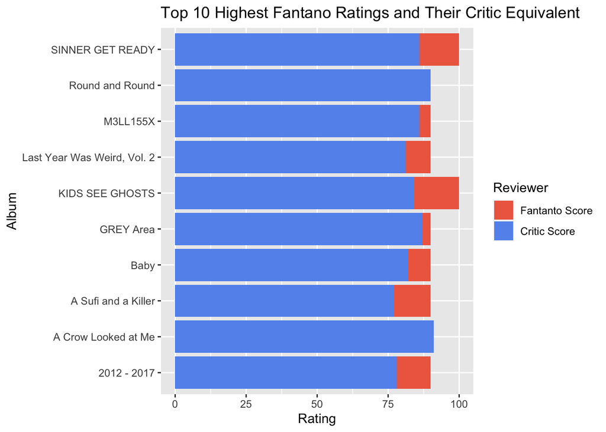

```r
top_ranking_difference <- highest_fantano_ratings %>%
  ggplot(aes(y = album)) +
  geom_col(aes(x = fantano_rating, fill = 'coral2')) +
  geom_col(aes(x= critic_score, fill = 'cornflowerblue'))+
  scale_fill_manual(
    name = 'Reviewer',
    values = c('coral2' = 'coral2', 'cornflowerblue' =
                 'cornflowerblue'),
    labels = c('Fantanto Score', 'Critic Score')
  ) +
  labs( x = 'Rating',
        y = 'Album',
        title = 'Top 10 Highest Fantano Ratings and Their Critic Equivalent')
```

#### Visualizing the difference between the lowest 10 fantno ratings and their critic equivalent rating

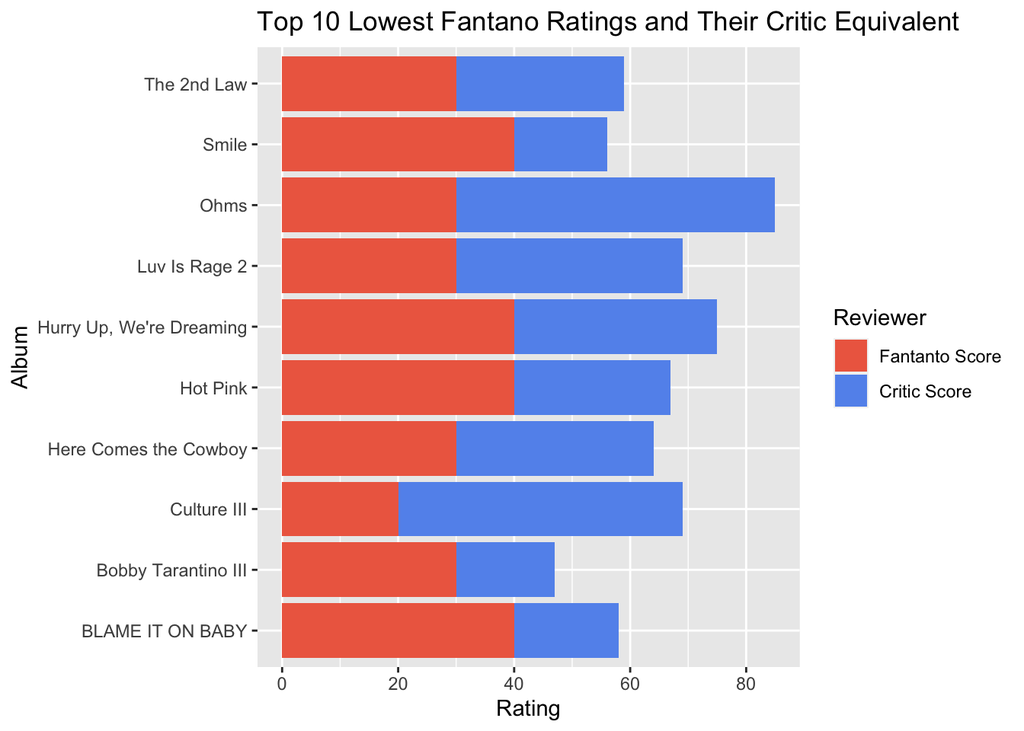

```r
lowest_ranking_difference <- lowest_fantano_ratings %>%
  ggplot(aes(y = album)) +
  geom_col(aes(x= critic_score, fill = 'cornflowerblue'))+
  geom_col(aes(x = fantano_rating, fill = 'coral2')) +
  scale_fill_manual(
    name = 'Reviewer',
    values = c('coral2' = 'coral2', 'cornflowerblue' =
                 'cornflowerblue'),
    labels = c('Fantanto Score', 'Critic Score')
  ) +
  labs( x = 'Rating',
        y = 'Album',
        title = 'Top 10 Lowest Fantano Ratings and Their Critic Equivalent')
```

#### Finding average fantano, critic, and user scores

#### Finding the difference between Fantano’s ratings and the critic’s ratings and also Fantano’s ratings and the user’s ratings

```r
average_fantano_rating <- mean(fantano_writeup$fantano_rating, na.rm = T)
average_critic_rating <- mean(fantano_writeup$critic_score, na.rm = T)
average_user_rating <- mean(as.double(fantano_writeup$user_score), na.rm = T)
average_critic_and_user <- (average_critic_rating + average_user_rating) /2
difference_in_critic_rating <- average_fantano_rating - average_critic_rating
difference_in_user_rating<- average_fantano_rating - average_user_rating
```

```
## [1] 63.68468
```

```
## [1] 73.807
```

```
## [1] 72.11268
```

```
## [1] 72.95984
```

```
## [1] -10.12232
```

```
## [1] -8.427991
```